# Relatório Mini-Projeto ATD

Feito por:João Cruz 2018288464, André Silva 2018277921, Mara Dias 2018276252

### Introdução

Neste trabalho utilizamos os vários conceitos obtidos nas aulas teóricas e práticas para analisar os data-sets fornecidos. Serão calculdas as DFTs dos sinais para obter a informação necessária.

## Exercicio 1

Foi feito o download dos data-sets.

## Exercicio 2

Código para leitura dos data-sets

```matlab
%Codigo para leitura dos ficheiros com os Data-sets
function filedata = read_raw_data(filename)
delimiter = ' ';
startRow = 1;
endRow = inf;
formatSpec = '%f%f%f%[^\n\r]';
fileID = fopen(filename,'r');
dataArray = textscan(fileID, formatSpec, endRow(1)-startRow(1)+1, 'Delimiter', delimiter, 'MultipleDelimsAsOne', true, 'TextType', 'string', 'EmptyValue', NaN, 'HeaderLines', startRow(1)-1, 'ReturnOnError', false, 'EndOfLine', '\r\n');
fclose(fileID);
filedata = [dataArray{1:end-1}];
```

```matlab
%Codigo para leitura das labels
function labels = importfileLabel(filename, startRow, endRow)
delimiter = ' ';
formatSpec = '%f%f%f%f%f%[^\n\r]';

fileID = fopen(filename,'r');

dataArray = textscan(fileID, formatSpec, endRow(1)-startRow(1)+1, 'Delimiter', delimiter, 'MultipleDelimsAsOne', true, 'TextType', 'string', 'HeaderLines', startRow(1)-1, 'ReturnOnError', false, 'EndOfLine', '\r\n');

fclose(fileID);

labels = [dataArray{1:end-1}];
```

```matlab
%Codigo para leitura das atividades
function activitylabels = importfileActLabel(filename)

delimiter = ' ';
startRow = 1;
endRow = inf;


formatSpec = '%s%s%[^\n\r]';


fileID = fopen(filename,'r');
dataArray = textscan(fileID, formatSpec, endRow(1)-startRow(1)+1, 'Delimiter', delimiter, 'MultipleDelimsAsOne', true, 'TextType', 'string', 'HeaderLines', startRow(1)-1, 'ReturnOnError', false, 'EndOfLine', '\r\n');
fclose(fileID);


activitylabels = [dataArray{1:end-1}];
```

```matlab
%Codigo que vai fazer a leitura de todos os ficheiros
dataPath = '.\DataSets PL3\';
Datasets=cell(1,10); % celula de 3 dimensoes com os valores dos datasets
j=1;
for i=11:20
    if i>=19 && i<=20
        Datasets{1,j}=read_raw_data([dataPath,'acc_exp',num2str(i),'_user',num2str(floor((i+1)/2)),'.txt']);
        j=j+1;
    else
        Datasets{1,j}=read_raw_data([dataPath,'acc_exp',num2str(i),'_user0',num2str(floor((i+1)/2)),'.txt']);
        j=j+1;
    end
end

labels=importfileLabel([dataPath,'labels.txt'],208,404);%vai ficar com os valores da label
acoes=importfileActLabel([dataPath,'activity_labels.txt']);

atividades=cell(3,12);%coluna representa os eixos, X Y e Z, e linhas as atividades (que são 12)
```

## Exercicio 3

Neste exercicio foi pedido para representar e identificar as várias atividades em cada ficheiro. A mudança de cor identifica uma mudança de atividade, enquanto a cor preta indica que não estão identificadas como nenhuma das 12 atividades.

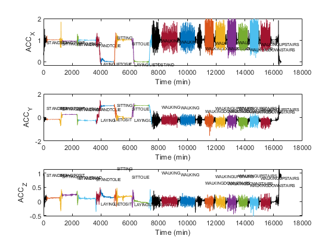

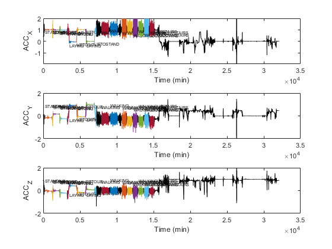

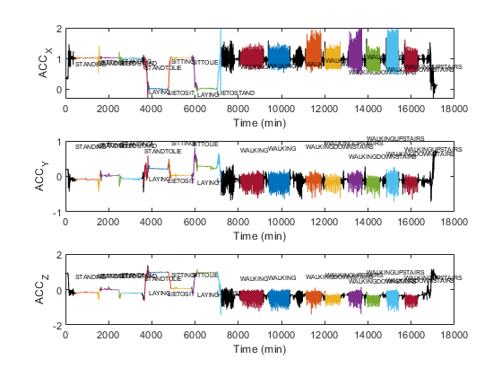

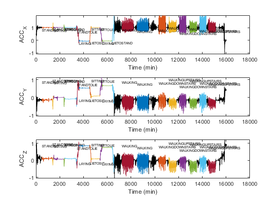

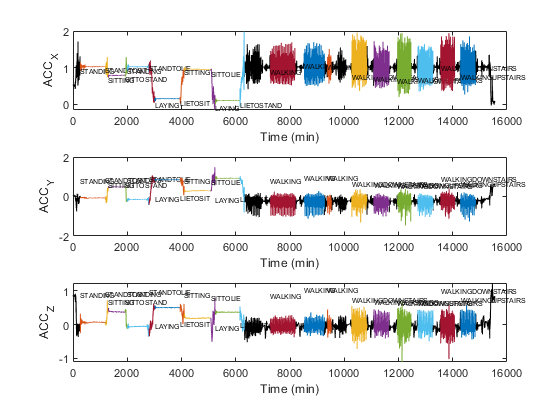

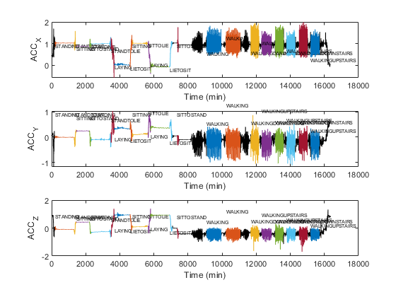

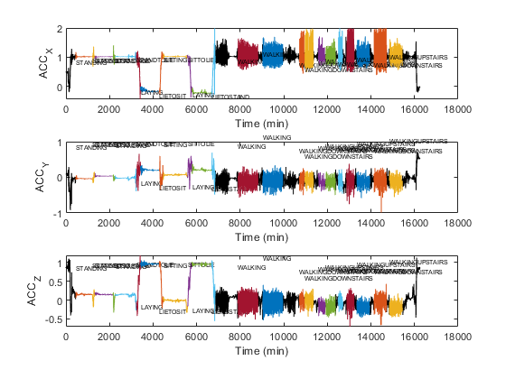

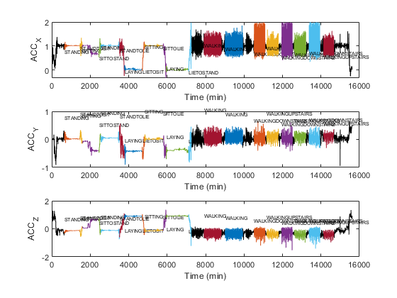

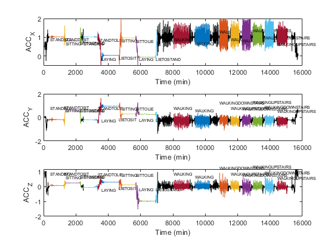

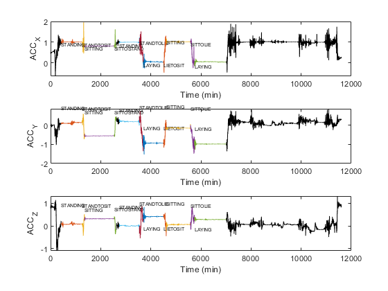

```matlab
counter=1;
for i=1:10
    x=Datasets{1,i}(:,1);%vai manter os valores de x do Dataset i
    y=Datasets{1,i}(:,2);%vai manter os valores de y do Dataset i
    z=Datasets{1,i}(:,3);%vai manter os valores de z do Dataset i
    eixoX=1:length(x);
    figure(i);
    subplot(311);
    plot(eixoX,x,'-k');
    xlabel('Time (min)');
    ylabel('ACC_X');
    subplot(312);
    plot(eixoX,y,'-k');
    xlabel('Time (min)');
    ylabel('ACC_Y');
    subplot(313);
    plot(eixoX,z,'-k');
    xlabel('Time (min)');
    ylabel('ACC_Z');
    linhaLabel=labels(counter,:);
    expAtual=linhaLabel(1);
    while expAtual==linhaLabel(1) && counter<197
         inicio=linhaLabel(4);
         fim=linhaLabel(5);
         atividade=linhaLabel(3);
         subplot(311);
         hold on;
         plot(inicio:fim,x(inicio:fim));
         texto=text(inicio,x(inicio),acoes(atividade,2),'VerticalAlignment','top','HorizontalAlignment','left');
         texto(1).FontSize = 5;
         subplot(312);
         hold on;
         plot(inicio:fim,y(inicio:fim));
         texto=text(inicio,x(inicio),acoes(atividade,2),'VerticalAlignment','top','HorizontalAlignment','left');
         texto(1).FontSize = 5;
         subplot(313);
         hold on;
         plot(inicio:fim,z(inicio:fim));
         texto=text(inicio,x(inicio),acoes(atividade,2),'VerticalAlignment','top','HorizontalAlignment','left');
         texto(1).FontSize = 5;
         counter=counter+1;

         atividades{1,atividade}{end+1}=x(inicio:fim);
         atividades{2,atividade}{end+1}=y(inicio:fim);
         atividades{3,atividade}{end+1}=z(inicio:fim);

         if(counter<197)
            linhaLabel=labels(counter,:);
         end
    end
end
```

## Exercicio 4

Em relação aos próximos exercicios tem-se em consideração os eixos seguintes:

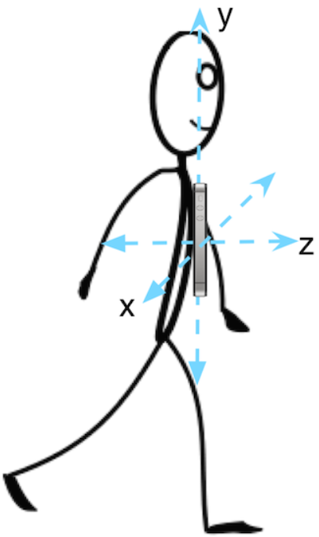

### Exercicio 4.1

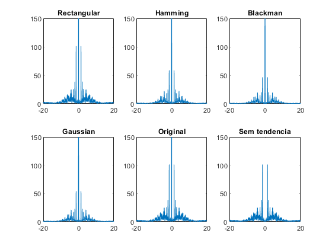

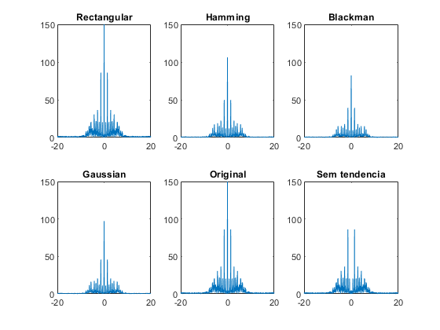

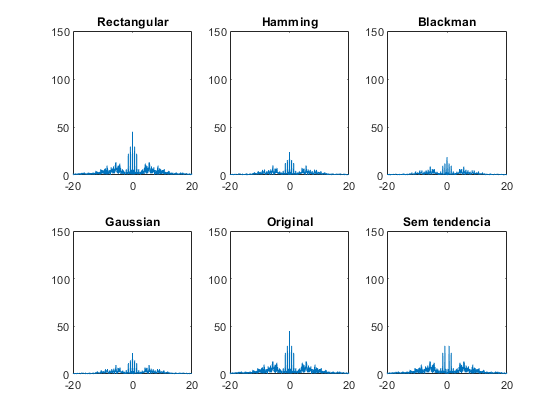

```matlab
dftx=dft(atividades(1,:),"all");
dfty=dft(atividades(2,:),"all");
dftz=dft(atividades(3,:),"all");
```

```matlab
function resultadoDFT = dft(atividade,janela)
Fs=40;
resultadoDFT=cell(1,12);
for i=1:12
    temp=atividade{1,i};
    tempDFT=cell(1,length(temp));
    for j=1:length(temp)
        temp2=temp{1,j}(:,1);
        N=length(temp2);

        if mod(N,2)==0
            f=-Fs/2:Fs/N:Fs/2-Fs/N;
        else
            f=-Fs/2+Fs/N/2:Fs/N:Fs/2-Fs/N/2;
        end

        if(janela=="retangular")
            janelaRect=rectwin(length(temp2));
            X = fftshift(fft(temp2.*janelaRect)); %calcular a dft do array multiplicado pela janela
            X(find(abs(X)<0.001))=0;
            plot(f,abs(X));
        elseif(janela=="hamming")
            janelaHamm=hamming(length(temp2));
            X = fftshift(fft(temp2.*janelaHamm));
            X(find(abs(X)<0.001))=0;
            plot(f,abs(X));
        elseif(janela=="Gaussian")
            janelaGauss=gausswin(length(temp2));
            X=fftshift(fft(temp2.*janelaGauss));
            X(find(abs(X)<0.001))=0;
            plot(f,abs(X));
            tempDFT{1,j}=X;
        elseif(janela=="Blackman")
            janelaBlack= blackman(length(temp2));
            X = fftshift(fft(detrend(temp2).*janelaBlack));
            X(find(abs(X)<0.001))=0;
            plot(f,abs(X));
        else
            Xoriginal = fftshift(fft(temp2));
            detrendTemp2 = detrend(temp2);
            Xdetrend=fftshift(fft(detrendTemp2));

            janelaHamming = hamming(length(temp2));
            janelaBlackman = blackman(length(temp2));
            janelaRectangular = rectwin(length(temp2));
            janelaGaussian = gausswin(length(temp2));


            XRect = fftshift(fft(temp2.*janelaRectangular));
            XRect(find(abs(XRect)<0.001))=0;

            XHamming=fftshift(fft(temp2.*janelaHamming));
            XHamming(find(abs(XHamming)<0.001))=0;

            XBlackman= fftshift(fft(temp2.*janelaBlackman));
            XBlackman(find(abs(XBlackman)<0.001))=0;

            XGaussian =fftshift(fft(temp2.*janelaGaussian));
            XGaussian(find(abs(XGaussian)<0.001))=0;

            if(i==1 && j==3)
                if(i==1)
                    lims=[0 150];
                elseif(i==5)
                    lims = [0 100];
                else
                    lims= [0 40];
                end
                figure();
                subplot(231);
                plot(f,abs(XRect));
                ylim(lims);
                title("Rectangular")

                subplot(232);
                plot(f,abs(XHamming));
                ylim(lims);
                title("Hamming")

                subplot(233);
                plot(f,abs(XBlackman));
                ylim(lims);
                title("Blackman");

                subplot(234);
                plot(f,abs(XGaussian));
                ylim(lims);
                title("Gaussian");

                subplot(235);
                plot(f,abs(Xoriginal));
                ylim(lims);
                title("Original");

                subplot(236);
                plot(f,abs(Xdetrend));
                ylim(lims);
                title("Sem tendencia");
            end

        end
    end
    resultadoDFT{1,i}=tempDFT;
end
end
```

### Exercicio 4.2

Para calcularmos o numero de passos nas atividades dinamicas, fomos obter os picos da DFT, para os diversos eixos, que correspondem aos valores mais significativos, do sinal. Estas correspondem ao numero de passos dado por segundo, assim para termos o numero de passos por minuto multiplicamos por 60.

| Eixo X | Walking | Walking Up | Walking Down |
| --- | --- | --- | --- |
| Média | 109,66 | 103,137 | 111,21 |
| Desvio | 4.15 | 8,5919 | 8.401 |

| Eixo Y | Walking | Walking Up | Walking Down |
| --- | --- | --- | --- |
| Média | 92,19 | 77,049 | 86,964 |
| Desvio | 24,85 | 27,112 | 28,78 |

| Eixo Z | Walking | Walking Up | Walking Down |
| --- | --- | --- | --- |
| Média | 83,93 | 71,09 | 88,07 |
| Desvio | 30,98 | 25,50 | 29,66 |

```matlab
[peakValx,freqx]=findPeaks(atividades(1,:));
[peakValy,freqy]=findPeaks(atividades(2,:));
[peakValz,freqz]=findPeaks(atividades(3,:));
```

```matlab
function [peakVal,freqVal]=findPeaks(activity)
fs=50;
peakVal=cell(1,12);
freqVal=cell(1,12);
media = zeros(1,3);
desvio = zeros(1,3);
passos=zeros(1,3);
for i=1:12
    peakRecenteValor=[];
    temp=activity{1,i};
    limiar=0.7;
    for j=1:length(temp)
        temp2=temp{1,j}(:,1);
        N = numel(temp2);
        if mod(N,2)==0
           f = -fs/2:fs/N:fs/2-fs/N;
        else
           f = -fs/2+fs/(2*N):fs/N:fs/2-fs/(2*N);
        end

        temp2=detrend(temp2);
        X = fftshift(fft(temp2));
        X(find(abs(X)<0.001))=0;
        m_X = abs(X);
        max_x = max(m_X);
        ind = find((m_X == max_x));

        min_mag =limiar*max_x;
        [peaks,locs] = findpeaks(m_X,'MinPeakHeight',min_mag);

        f_relevant = f(locs);
        peaks=peaks(f_relevant>=0);

        f_relevant = f_relevant(f_relevant>=0);


        firstPeaks{1,j}=f_relevant(1)*60;
        %f_relevant = round(f_relevant);
        freqVal{1,i}(j)=f_relevant(1);
        peak = abs(m_X(locs));
        peakRecenteValor{1,j}=peak;

    end
    if(i<=3)
        media(1,i)= mean(cell2mat(firstPeaks));%passos por minuto
        desvio(1,i)= std(cell2mat(firstPeaks));
    end
    peakVal{1,i}=peakRecenteValor;
end
media
desvio
end
```

### Exercicio 4.3

Nesta parte do exercicio é pedida a distinção entre os diferentes tipos de atividades, neste caso em particular entre as atividades estáticas e de transição com as dinamicas.

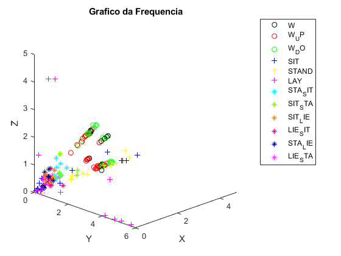

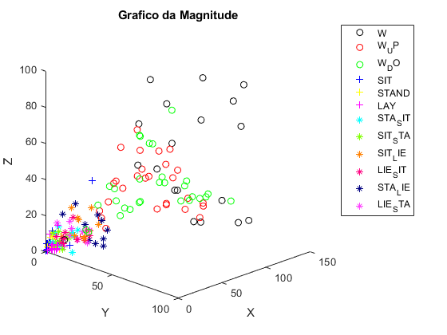

```matlab
graphActivityFrequencia(freqx,freqy,freqz);
graphActivity(peakValx,peakValy,peakValz);
```

Através destes graficos é possivel confirmar que as atividades estáticas e de transição têm magnitudes mais baixas, concentrando-se nos pontos mais baixos do grafico, já as atividades dinâmicas têm maior magnitude e portanto encontram-se em partes superiores. Em relação á performance em termos de sensibilidade da distinção das atividades, podemos afirmar que as dinâmicas são de fácil distinção das restantes olhando para a magnitude e frequencia do sinal. Explica-se pelo facto que uma atividade dinâmica gera muito mais movimento e assim mais amplitude nas frequências presentes. As restantes geram menos movimentos e assim as amplitudes correspondentes a cada frequência presente no sinal serão muito menores.

```matlab
function graphActivity(X,Y,Z)
color = [[0,0,0];[1,0,0];[0,1,0];[0,0,1];[1,1,0];[1,0,1];[0,1,1];[0.5,1,0];[1,0.5,0];[1,0,0.5];[0,0,0.5];[1,0.25,1]];
forma = ['o','o','o','+','+','+','*','*','*','*','*','*'];
for i=1:12

    tempX=X{1,i};
    tempY=Y{1,i};
    tempZ=Z{1,i};
    finalX=[];
    finalY=[];
    finalZ=[];
    for j=1:length(tempX)
        finalX(j)=tempX{1,j}(1,:);
        finalY(j)=tempY{1,j}(1,:);
        finalZ(j)=tempZ{1,j}(1,:);
    end
    figure(30);
    title("Grafico da Magnitude");
    c = color(i,:);
    hold on;
    plot3(finalX,finalY,finalZ,forma(i),'color',c);
    view(45,-20);
    ylabel("Y");
    xlabel("X");
    zlabel("Z");
end
legend('W',"W_UP","W_DO","SIT","STAND","LAY","STA_SIT","SIT_STA","SIT_LIE","LIE_SIT","STA_LIE","LIE_STA");
end

function graphActivityFrequencia(freqX,freqY,freqZ)

color = [[0,0,0];[1,0,0];[0,1,0];[0,0,1];[1,1,0];[1,0,1];[0,1,1];[0.5,1,0];[1,0.5,0];[1,0,0.5];[0,0,0.5];[1,0.25,1]];
forma = ['o','o','o','+','+','+','*','*','*','*','*','*'];
figure(50);
title("Grafico da Frequencia");
for i=1:12

    tempX=freqX{1,i};
    tempY=freqY{1,i};
    tempZ=freqZ{1,i};
    c = color(i,:);
    hold on;
    plot3(tempX,tempY,tempZ,forma(i),'color',c);
    view(45,-20);
    ylabel("Y");
    xlabel("X");
    zlabel("Z");
end
legend('W',"W_UP","W_DO","SIT","STAND","LAY","STA_SIT","SIT_STA","SIT_LIE","LIE_SIT","STA_LIE","LIE_STA");
end
```

### Exercicio 4.4

Para este exercicio fomos calcular a DFT do sinal para cada atividade para podermos compará-las. Os graficos seguintes estão por ordem de Atividade

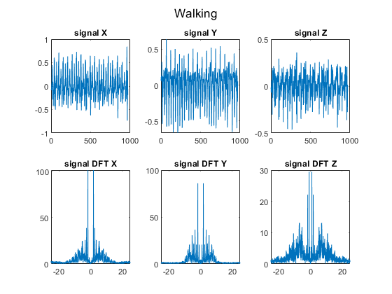

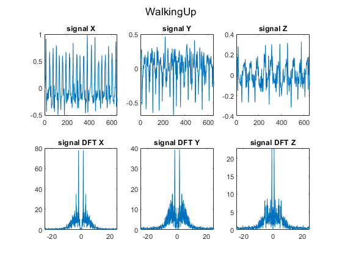

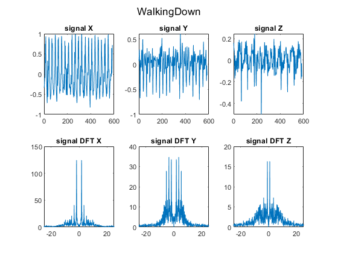

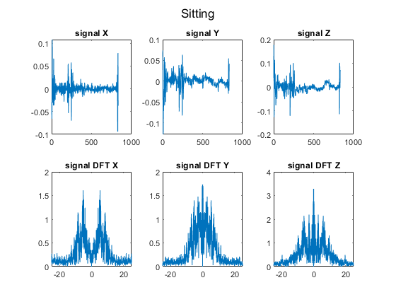

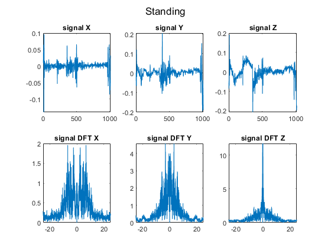

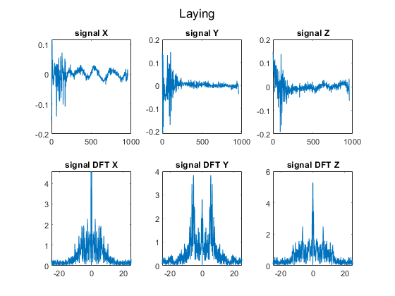

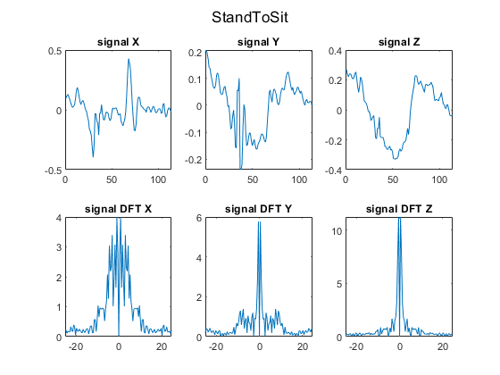

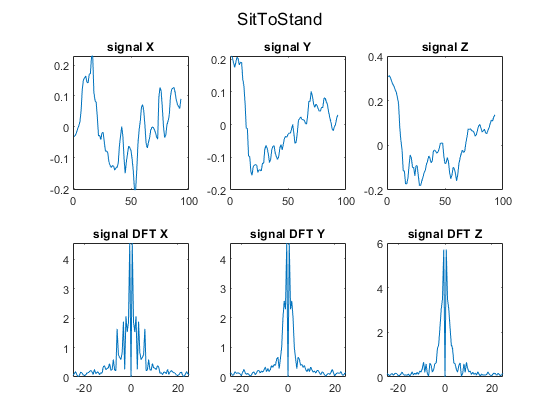

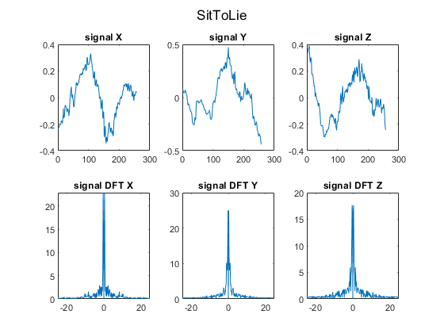

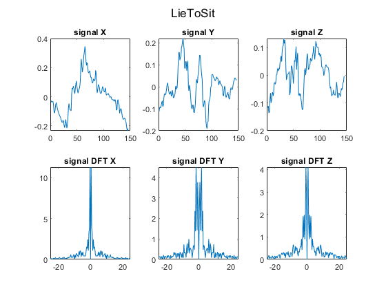

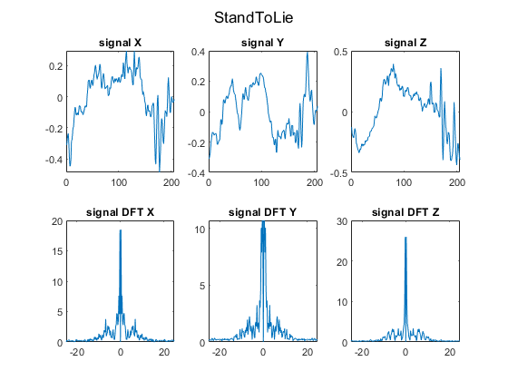

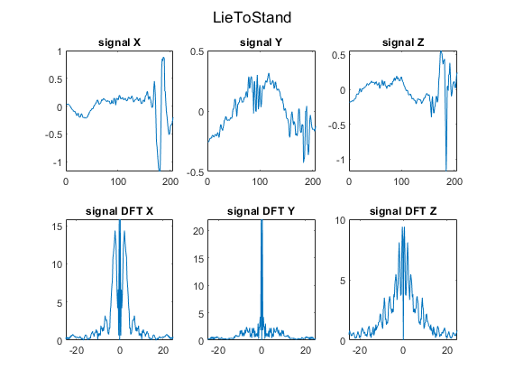

```matlab
graphSignalDFT(atividades);
```

Nas atividas dinâmicas nota-se que tem mais picos e maiores frequencias quando comparado aos restantes tipos de atividade. Tambem a magnitude da DFT nas atividades estáticas serão muito menores em relação as atividades de transição, acontecendo devido as grandes diferenças nos eixos mostrando-se pela magnitude do sinal.

### Exercicio 4.5

Entre o Walking e os outros 2 tipos de Walking verifica-se que este possui componentes de magnitude no eixo do Z mais elevado que os outros, possivelmente porque a movimentação do individuo é mais notória na direção Z, enquanto que os restantes terão maior movimentação no eixo vertical dos Y. Em relação a walking down e walking up é possivel observer diferenças espetrais nas magnitudes. Apesar da separação não ser perfeita, havendo alguns falsos postivios e falso negativos, ainda é possivel observar que no walking down a magnitude no eixo dos Y é marioritariamente maior que no walking down. É possivel também observar um plano que separa ambas as atividades

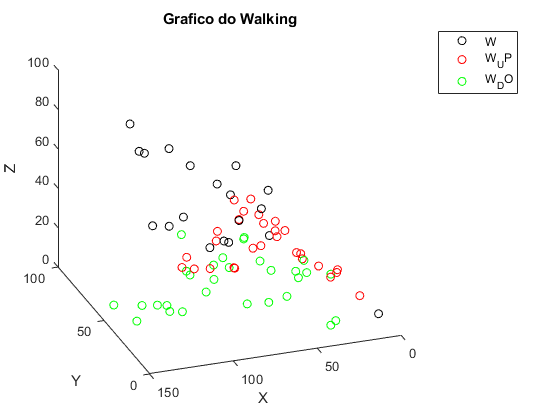

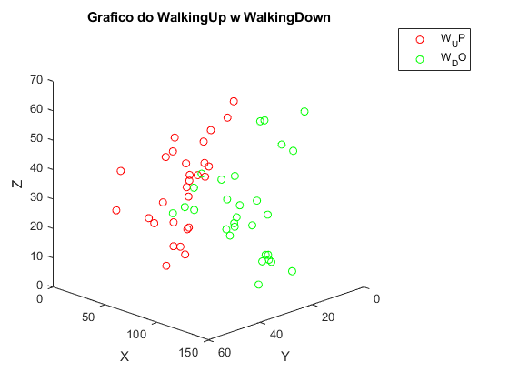

```matlab
graphActivityWalking(peakValx,peakValy,peakValz);
graphActivityFreqWalking(peakValx,peakValy,peakValz);
```

```matlab
function graphActivityWalking(X,Y,Z)
color = [[0,0,0];[1,0,0];[0,1,0];[0,0,1];[1,1,0];[1,0,1];[0,1,1];[0.5,1,0];[1,0.5,0];[1,0,0.5];[0,0,0.5];[1,0.25,1]];
forma = ['o','o','o','+','+','+','*','*','*','*','*','*'];
for i=2:3

    tempX=X{1,i};
    tempY=Y{1,i};
    tempZ=Z{1,i};
    finalX=[];
    finalY=[];
    finalZ=[];
    for j=1:length(tempX)
        finalX(j)=tempX{1,j}(1,:);
        finalY(j)=tempY{1,j}(1,:);
        finalZ(j)=tempZ{1,j}(1,:);
    end
    figure(60);
    title("Grafico do WalkingUp w WalkingDown");
    c = color(i,:);
    hold on;
    plot3(finalX,finalY,finalZ,forma(i),'color',c);
    view(-45,-20);
    ylabel("Y");
    xlabel("X");
    zlabel("Z");
end
legend("W_UP","W_DO");
end

function graphActivityFreqWalking(X,Y,Z)

color = [[0,0,0];[1,0,0];[0,1,0];[0,0,1];[1,1,0];[1,0,1];[0,1,1];[0.5,1,0];[1,0.5,0];[1,0,0.5];[0,0,0.5];[1,0.25,1]];
forma = ['o','o','o','+','+','+','*','*','*','*','*','*'];
figure(55);
for i=1:3

    tempX=X{1,i};
    tempY=Y{1,i};
    tempZ=Z{1,i};
    finalX=[];
    finalY=[];
    finalZ=[];
    for j=1:length(tempX)
        finalX(j)=tempX{1,j}(1,:);
        finalY(j)=tempY{1,j}(1,:);
        finalZ(j)=tempZ{1,j}(1,:);
    end
    title("Grafico do Walking");
    c = color(i,:);
    hold on;
    plot3(finalX,finalY,finalZ,forma(i),'color',c);
    view(200,-30);
    ylabel("Y");
    xlabel("X");
    zlabel("Z");
end
legend("W","W_UP","W_DO");
end
```